# Mate-choice copying in non-human animals: an update of two meta-analyses

Concise Supplement — Results Aligned with the Main Text

Author

Eduardo S. A. Santos & Collaborators

Published

July 2026

**NoteWhat this page is**

This is a **concise companion** to the manuscript. It reproduces only the numbers, tables, and figures that the main text actually reports, section by section, with a sentence or two of plain-language context for each. It is meant for readers and reviewers who want the headline evidence without the full computational trail.

The complete, fully reproducible workflow — data loading, model code, saved model objects, and every diagnostic — remains in the detailed supplement:

- Full reproducible book: https://esantos2ua.github.io/mate_choice_meta/
- Source repository: https://github.com/esantos2ua/mate_choice_meta

Figures shown here are the same files generated by that pipeline; the estimates are transcribed from the frozen model outputs reported in the manuscript. Code blocks are folded — click **“Show code”** to see how each summary table is assembled.

# Screening outcomes and dataset

We added **69 new effect sizes from 29 studies**, spanning **15 species**. Notably, 13 of the new studies (45%) were published in or before 2019 — inside the search window of the original meta-analyses — and six (20.7%) were unpublished theses, reflecting the value of the multilingual and grey-literature search. Two model genera dominate the evidence: *Drosophila* (11 studies) and *Poecilia* (8 studies) together contribute 46 effect sizes (66%). When pooled with the two original datasets, the combined sample covers **33 species**.

```r
dataset <- data.frame(
  Quantity = c("New effect sizes", "New studies", "Species (new extraction)",
               "Studies published ≤2019", "Unpublished theses",
               "Effect sizes from Drosophila + Poecilia", "Species (combined dataset)"),
  Value = c("69", "29", "15", "13 (45%)", "6 (20.7%)", "46 (66%)", "33")
)
tbl(dataset, "Table 1. Key descriptors of the updated dataset.")
```

Table 1: Table 1. Key descriptors of the updated dataset.

| Quantity | Value |
| --- | --- |
| New effect sizes | 69 |
| New studies | 29 |
| Species (new extraction) | 15 |
| Studies published ≤2019 | 13 (45%) |
| Unpublished theses | 6 (20.7%) |
| Effect sizes from Drosophila + Poecilia | 46 (66%) |
| Species (combined dataset) | 33 |

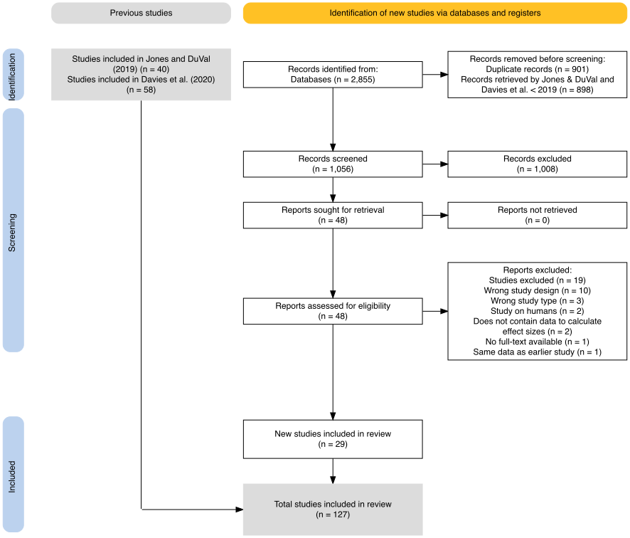

Figure 1: **PRISMA flowchart.** Identification, screening, eligibility, and inclusion stages for the update.

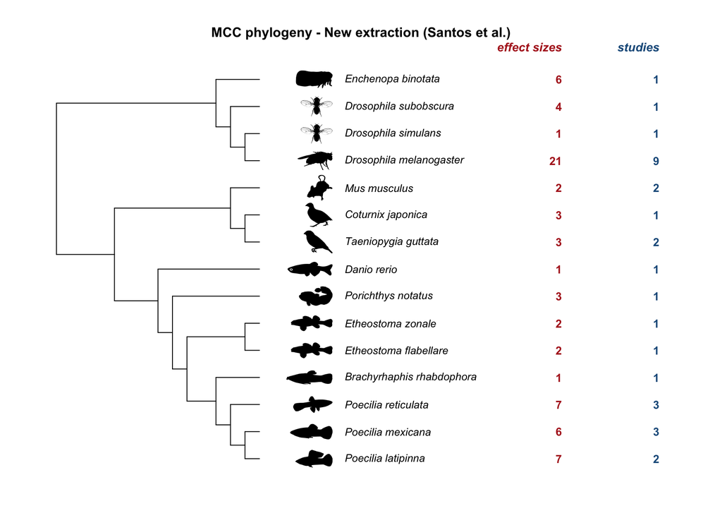

Figure 2: **Phylogeny (new extraction).** The 15 species of the new extraction, with per-species effect-size and study counts.

# Overall evidence for mate-choice copying

The pooled effect of social information stayed **positive and significant on both scales** in the combined data, but was **appreciably smaller than the original estimates**. Considered on its own, the new evidence was roughly half the original magnitude, with confidence intervals spanning the null.

```r
overall <- data.frame(
  Scale = c("Odds ratio (OR)", "Odds ratio (OR)", "Odds ratio (OR)",
            "Hedges' g / d", "Hedges' g / d", "Hedges' g / d"),
  Dataset = c("Original (Jones & DuVal 2019)", "New (this study)", "Combined",
              "Original (Davies et al. 2020)", "New (this study)", "Combined"),
  Estimate = c("2.71", "1.46", "1.81", "0.58", "0.21", "0.45"),
  `95% interval` = c("1.60 to 4.80", "0.97 to 2.20", "1.35 to 2.42",
                     "0.34 to 0.83", "-0.02 to 0.43", "0.24 to 0.65"),
  Note = c("posterior CrI", "spans null", "significant",
           "reported as d", "spans null", "significant"),
  check.names = FALSE
)
tbl(overall, "Table 2. Overall meta-analytic mean on each scale, for the original, new, and combined datasets.")
```

Table 2: Table 2. Overall meta-analytic mean on each scale, for the original, new, and combined datasets.

| Scale | Dataset | Estimate | 95% interval | Note |
| --- | --- | --- | --- | --- |
| Odds ratio (OR) | Original (Jones & DuVal 2019) | 2.71 | 1.60 to 4.80 | posterior CrI |
| Odds ratio (OR) | New (this study) | 1.46 | 0.97 to 2.20 | spans null |
| Odds ratio (OR) | Combined | 1.81 | 1.35 to 2.42 | significant |
| Hedges’ g / d | Original (Davies et al. 2020) | 0.58 | 0.34 to 0.83 | reported as d |
| Hedges’ g / d | New (this study) | 0.21 | -0.02 to 0.43 | spans null |
| Hedges’ g / d | Combined | 0.45 | 0.24 to 0.65 | significant |

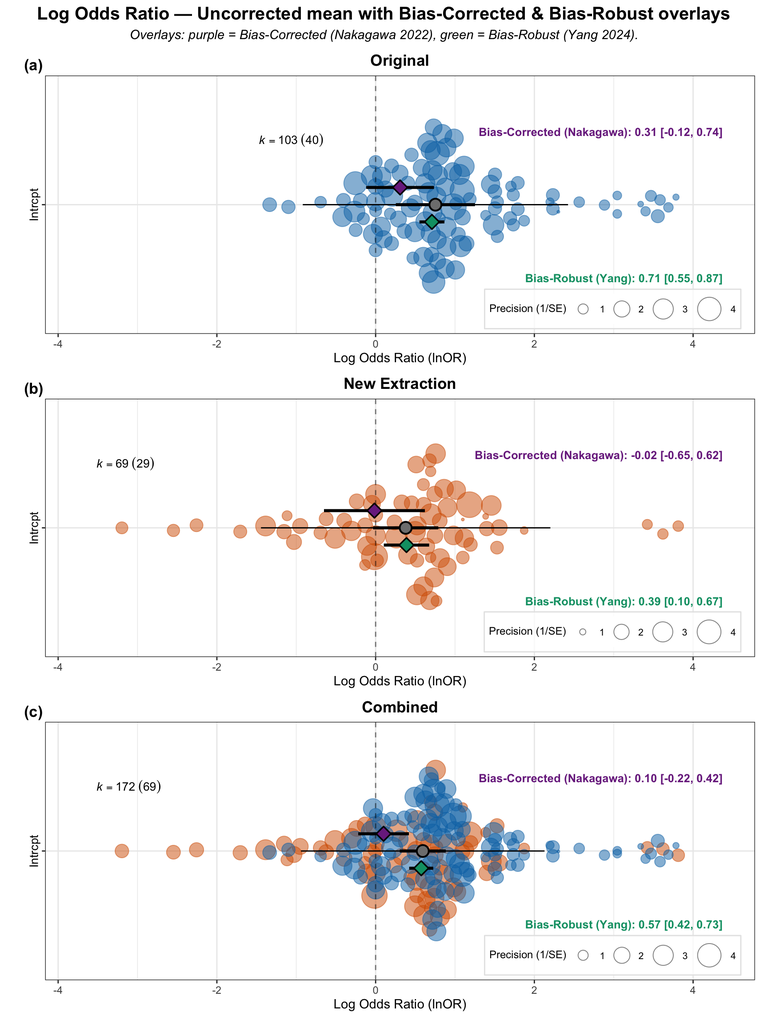

Figure 3: **Log odds ratio.** Uncorrected (grey), bias-corrected (Nakagawa; purple) and bias-robust (Yang; green) means for original (a), new (b), and combined (c) data.

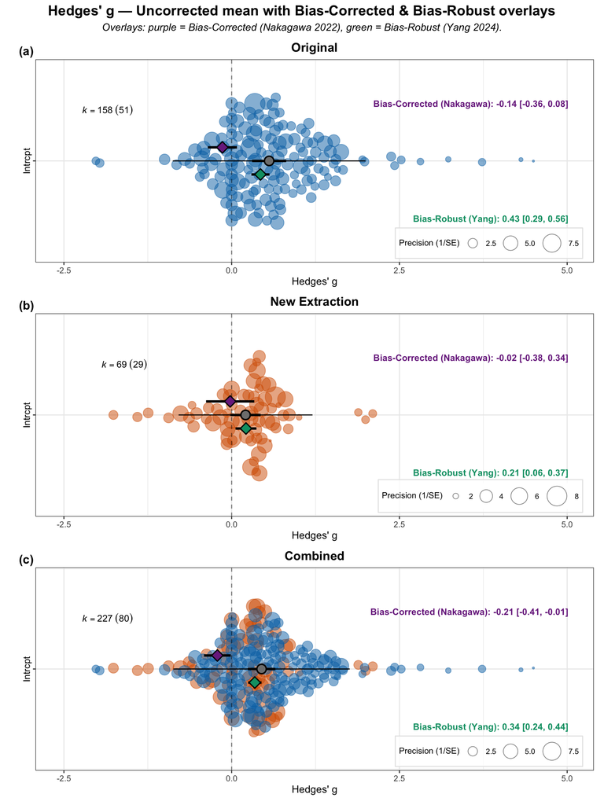

Figure 4: **Hedges’ g.** Uncorrected (grey), bias-corrected (Nakagawa; purple) and bias-robust (Yang; green) means for original (a), new (b), and combined (c) data.

## Heterogeneity

```r
i2 <- data.frame(
  Analysis = c("Hedges' g — New only", "Hedges' g — Original only", "Hedges' g — Combined",
               "Log OR — New only", "Log OR — Original only", "Log OR — Combined"),
  Total    = c(80.8, 86.0, 85.7, 80.8, 75.9, 74.7),
  Study     = c(0.0, 1.2, 7.4, 0.0, 0.0, 4.3),
  `Effect size (residual)` = c(51.3, 79.4, 71.7, 51.3, 23.2, 45.4),
  `Species (non-phylo.)`   = c(29.4, 0.0, 3.1, 29.5, 45.6, 23.9),
  Phylogeny = c(0.0, 5.4, 3.5, 0.0, 7.1, 1.1),
  check.names = FALSE
)
tbl(i2, "Table 3. Partial I² (%) by random effect across the uncorrected multilevel models.")
```

Table 3: Table 3. Partial I² (%) by random effect across the uncorrected multilevel models.

| Analysis | Total | Study | Effect size (residual) | Species (non-phylo.) | Phylogeny |
| --- | --- | --- | --- | --- | --- |
| Hedges’ g — New only | 80.8 | 0.0 | 51.3 | 29.4 | 0.0 |
| Hedges’ g — Original only | 86.0 | 1.2 | 79.4 | 0.0 | 5.4 |
| Hedges’ g — Combined | 85.7 | 7.4 | 71.7 | 3.1 | 3.5 |
| Log OR — New only | 80.8 | 0.0 | 51.3 | 29.5 | 0.0 |
| Log OR — Original only | 75.9 | 0.0 | 23.2 | 45.6 | 7.1 |
| Log OR — Combined | 74.7 | 4.3 | 45.4 | 23.9 | 1.1 |

# Taxonomic group

All group means were positive on both scales. On the Hedges’ g scale the point estimates rose from arthropods to fish to other vertebrates, and the among-group test only approached significance; on the log-odds scale the ranking differed and the groups did not differ significantly.

```r
taxon <- data.frame(
  Scale = c("Hedges' g", "Hedges' g", "Hedges' g",
            "Log OR", "Log OR", "Log OR"),
  Group = c("Arthropods", "Fish", "Other vertebrates (birds, mammals)",
            "Fish", "Other vertebrates (birds, mammals)", "Arthropods"),
  Estimate = c("0.24", "0.49", "0.71", "0.82", "0.61", "0.33"),
  `95% CI` = c("0.01 to 0.46", "0.28 to 0.69", "0.36 to 1.07",
               "0.37 to 1.26", "-0.04 to 1.25", "-0.13 to 0.80"),
  check.names = FALSE
)
tbl(taxon, "Table 4. Uni-moderator estimates by taxonomic group (combined datasets).")
```

Table 4: Table 4. Uni-moderator estimates by taxonomic group (combined datasets).

| Scale | Group | Estimate | 95% CI |
| --- | --- | --- | --- |
| Hedges’ g | Arthropods | 0.24 | 0.01 to 0.46 |
| Hedges’ g | Fish | 0.49 | 0.28 to 0.69 |
| Hedges’ g | Other vertebrates (birds, mammals) | 0.71 | 0.36 to 1.07 |
| Log OR | Fish | 0.82 | 0.37 to 1.26 |
| Log OR | Other vertebrates (birds, mammals) | 0.61 | -0.04 to 1.25 |
| Log OR | Arthropods | 0.33 | -0.13 to 0.80 |

Among-group tests: Hedges’ g, Wald $Q_M = 3.06$, *p* = 0.06 (total $I^2$ = 94.3%); log OR, Wald $Q_M = 1.17$, *p* = 0.33 (total $I^2$ = 89.5%).

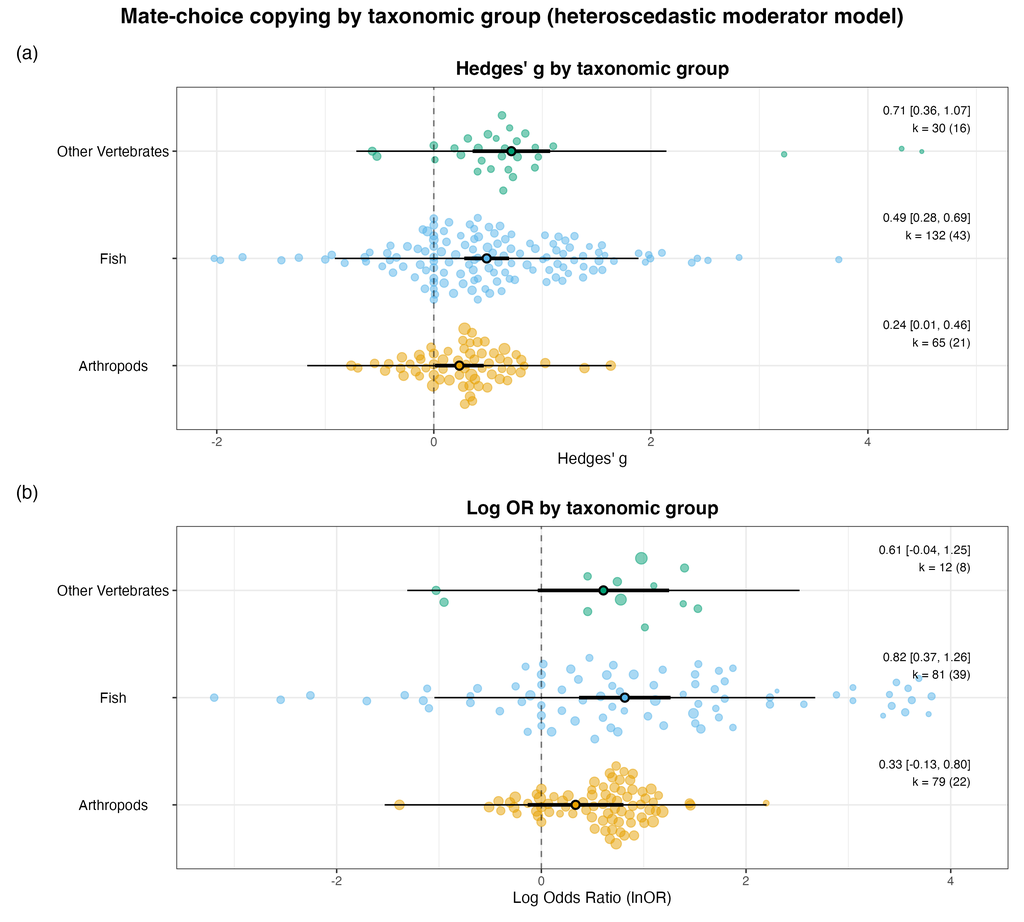

Figure 5: **Taxon moderator.** (a) Hedges’ g and (b) log odds ratio, by taxonomic group.

# Exploratory (non-pre-registered) moderators

Beyond taxonomic group we examined copying mechanism, cue modality, observer mating status, and demonstrator age. These were exploratory, several levels are sparsely sampled, and **no moderator explained a detectable share of the heterogeneity** (all Wald $Q_M$, *p* > 0.2; total $I^2$ stayed above 80%). Two contrasts are worth noting.

```r
mods <- data.frame(
  Contrast = c("Copying mechanism (combined, Hedges' g)",
               "Copying mechanism (new, Hedges' g)",
               "Observer status (new, Hedges' g)",
               "Observer status (combined, OR)"),
  Comparison = c("generalized 0.44 vs individual 0.44",
                 "generalized 0.26 vs individual 0.16",
                 "virgin 0.09 vs non-virgin 0.36",
                 "virgin 1.75 vs non-virgin 1.91"),
  Test = c("Q_M = 0.003, p = 0.96",
           "p > 0.5",
           "Q_M = 1.61, p = 0.22",
           "p = 0.72")
)
tbl(mods, "Table 5. Selected exploratory moderator contrasts. None was statistically distinct.")
```

Table 5: Table 5. Selected exploratory moderator contrasts. None was statistically distinct.

| Contrast | Comparison | Test |
| --- | --- | --- |
| Copying mechanism (combined, Hedges’ g) | generalized 0.44 vs individual 0.44 | Q_M = 0.003, p = 0.96 |
| Copying mechanism (new, Hedges’ g) | generalized 0.26 vs individual 0.16 | p > 0.5 |
| Observer status (new, Hedges’ g) | virgin 0.09 vs non-virgin 0.36 | Q_M = 1.61, p = 0.22 |
| Observer status (combined, OR) | virgin 1.75 vs non-virgin 1.91 | p = 0.72 |

Generalized and individual copying were statistically indistinguishable (if anything, generalized was marginally stronger). Unlike Jones & DuVal (2019), the new extraction did **not** reproduce stronger copying among virgin observers — it tended to reverse it — and the difference vanished once pooled with the original binary data. Full model summaries and orchard plots for every moderator are in the [full reproducible book](https://esantos2ua.github.io/mate_choice_meta/).

# Small-study effects, time-lag, and sensitivity

We found **strong small-study effects on both scales** and **a time-lag decline only for the binary outcomes**. Under the more conservative correction the adjusted mean approached zero — and for Hedges’ g fell significantly below it — whereas the bias-robust estimator kept a positive but reduced effect.

```r
eggers <- data.frame(
  Scale = c("Odds ratio", "Hedges' g"),
  `Egger slope (√v_i)` = c("2.11 (1.23 to 2.99)", "4.36 (3.22 to 5.49)"),
  `Time-lag slope (year)` = c("-0.028 (-0.048 to -0.007)", "-0.002 (-0.014 to 0.01)"),
  `Time-lag?` = c("yes (declining)", "no"),
  check.names = FALSE
)
tbl(eggers, "Table 6. Small-study (Egger-type) and time-lag slopes on the combined data.")
```

Table 6: Table 6. Small-study (Egger-type) and time-lag slopes on the combined data.

| Scale | Egger slope (√v_i) | Time-lag slope (year) | Time-lag? |
| --- | --- | --- | --- |
| Odds ratio | 2.11 (1.23 to 2.99) | -0.028 (-0.048 to -0.007) | yes (declining) |
| Hedges’ g | 4.36 (3.22 to 5.49) | -0.002 (-0.014 to 0.01) | no |

```r
corr <- data.frame(
  Scale = c("Hedges' g", "Hedges' g", "Hedges' g",
            "Log OR (OR)", "Log OR (OR)", "Log OR (OR)"),
  Estimator = c("Uncorrected", "Bias-corrected (Nakagawa)", "Bias-robust (Yang)",
                "Uncorrected", "Bias-corrected (Nakagawa)", "Bias-robust (Yang)"),
  Mean = c("0.45", "-0.21", "0.34",
           "0.59 (OR 1.81)", "0.10 (OR 1.11)", "0.57 (OR 1.77)"),
  `95% CI` = c("0.24 to 0.65", "-0.41 to -0.01", "0.24 to 0.44",
               "0.30 to 0.89", "-0.22 to 0.42", "0.42 to 0.73"),
  check.names = FALSE
)
tbl(corr, "Table 7. Uncorrected vs. the two publication-bias-corrected means (combined data).")
```

Table 7: Table 7. Uncorrected vs. the two publication-bias-corrected means (combined data).

| Scale | Estimator | Mean | 95% CI |
| --- | --- | --- | --- |
| Hedges’ g | Uncorrected | 0.45 | 0.24 to 0.65 |
| Hedges’ g | Bias-corrected (Nakagawa) | -0.21 | -0.41 to -0.01 |
| Hedges’ g | Bias-robust (Yang) | 0.34 | 0.24 to 0.44 |
| Log OR (OR) | Uncorrected | 0.59 (OR 1.81) | 0.30 to 0.89 |
| Log OR (OR) | Bias-corrected (Nakagawa) | 0.10 (OR 1.11) | -0.22 to 0.42 |
| Log OR (OR) | Bias-robust (Yang) | 0.57 (OR 1.77) | 0.42 to 0.73 |

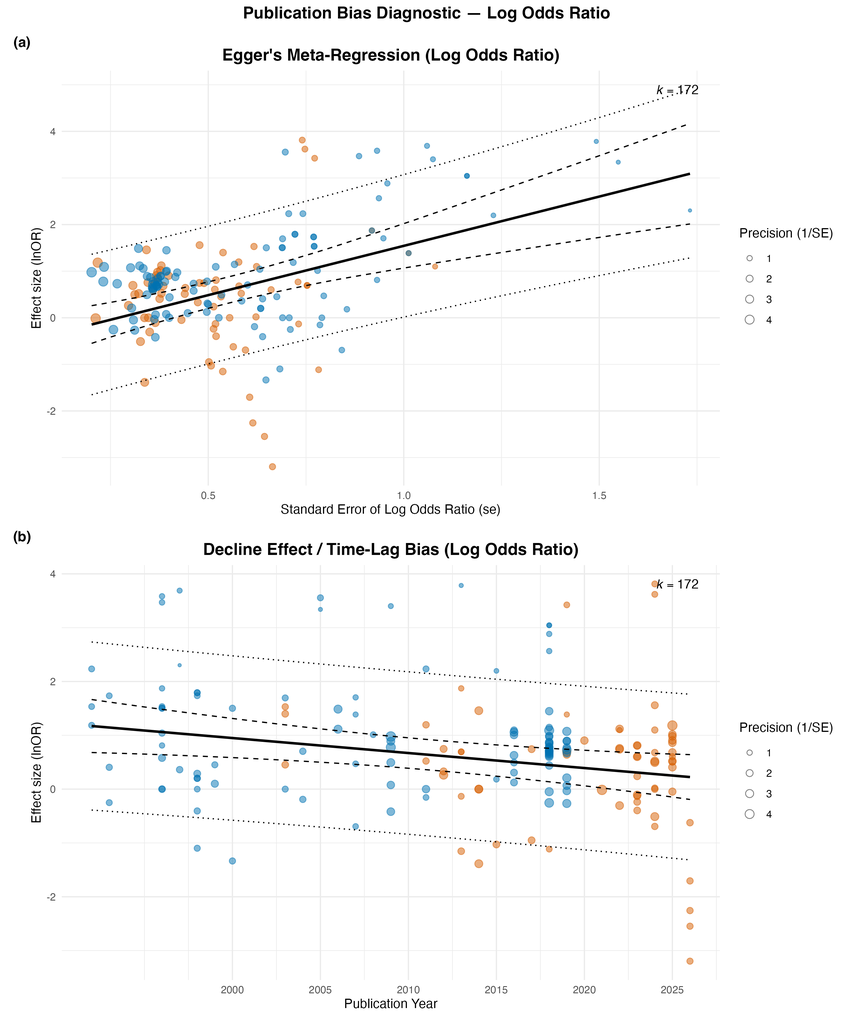

Figure 6: **Publication-bias diagnostic — odds ratio.** Effect size vs (a) √variance and (b) publication year.

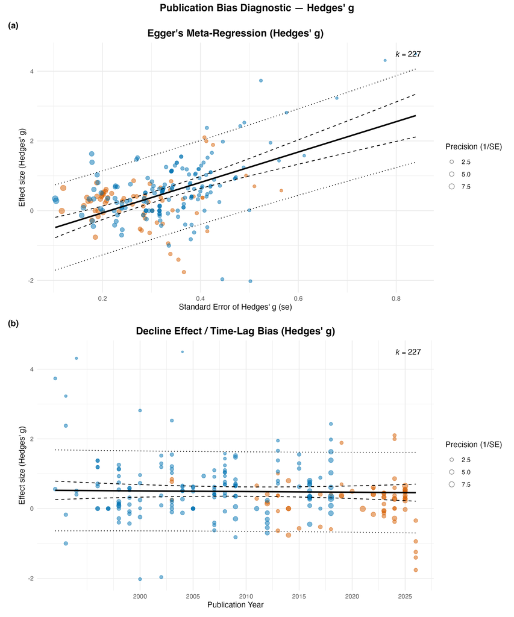

Figure 7: **Publication-bias diagnostic — Hedges’ g.** Effect size vs (a) √variance and (b) publication year.

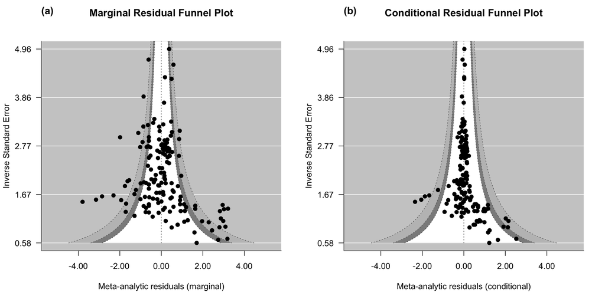

Figure 8: **Funnel plot — odds ratio** (marginal vs conditional residuals).

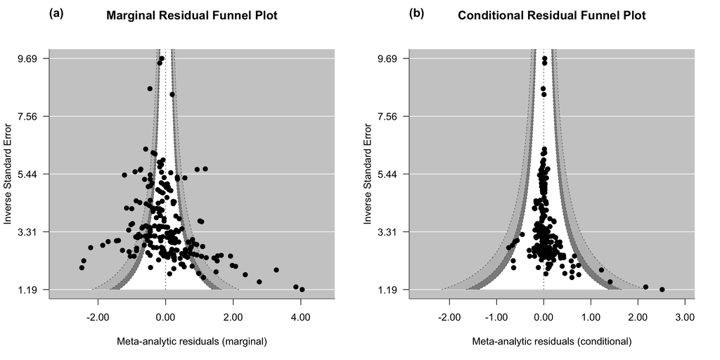

Figure 9: **Funnel plot — Hedges’ g** (marginal vs conditional residuals).

## Robustness: leave-one-out and contentious effect sizes

```r
sens <- data.frame(
  Scale = c("Hedges' g", "Hedges' g", "Hedges' g",
            "Odds ratio", "Odds ratio", "Odds ratio"),
  Version = c("Main", "Leave-out (7 flagged studies)", "Corrected",
              "Main", "Leave-out (7 flagged studies)", "Corrected"),
  Mean = c("0.44", "0.42", "0.42", "1.81", "1.77", "1.79"),
  `95% CI` = c("0.24 to 0.65", "0.22 to 0.61", "0.23 to 0.62",
               "1.35 to 2.42", "1.32 to 2.38", "1.36 to 2.34"),
  k = c("227", "213", "225", "172", "156", "169"),
  check.names = FALSE
)
tbl(sens, "Table 8. Sensitivity of the combined means to the seven contentious cross-dataset studies.")
```

Table 8: Table 8. Sensitivity of the combined means to the seven contentious cross-dataset studies.

| Scale | Version | Mean | 95% CI | k |
| --- | --- | --- | --- | --- |
| Hedges’ g | Main | 0.44 | 0.24 to 0.65 | 227 |
| Hedges’ g | Leave-out (7 flagged studies) | 0.42 | 0.22 to 0.61 | 213 |
| Hedges’ g | Corrected | 0.42 | 0.23 to 0.62 | 225 |
| Odds ratio | Main | 1.81 | 1.35 to 2.42 | 172 |
| Odds ratio | Leave-out (7 flagged studies) | 1.77 | 1.32 to 2.38 | 156 |
| Odds ratio | Corrected | 1.79 | 1.36 to 2.34 | 169 |

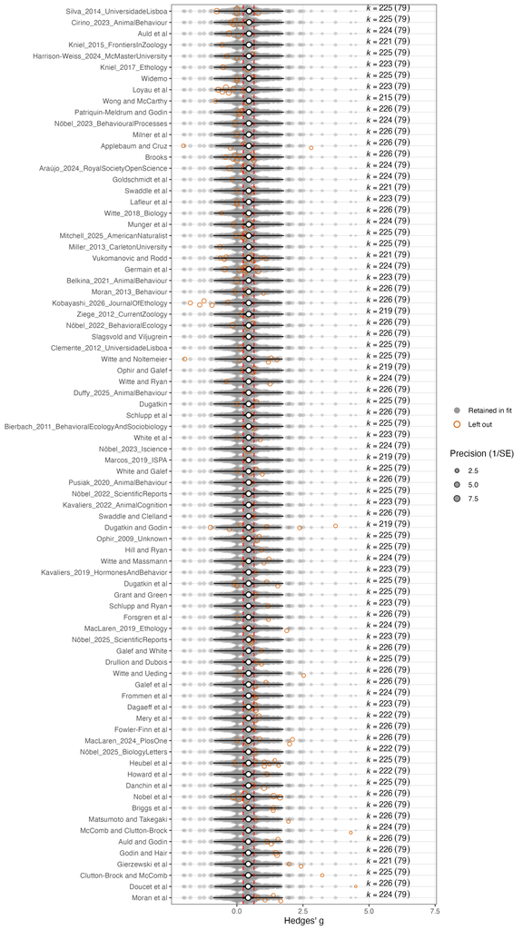

Figure 10: **Leave-one-study-out — Hedges’ g.**

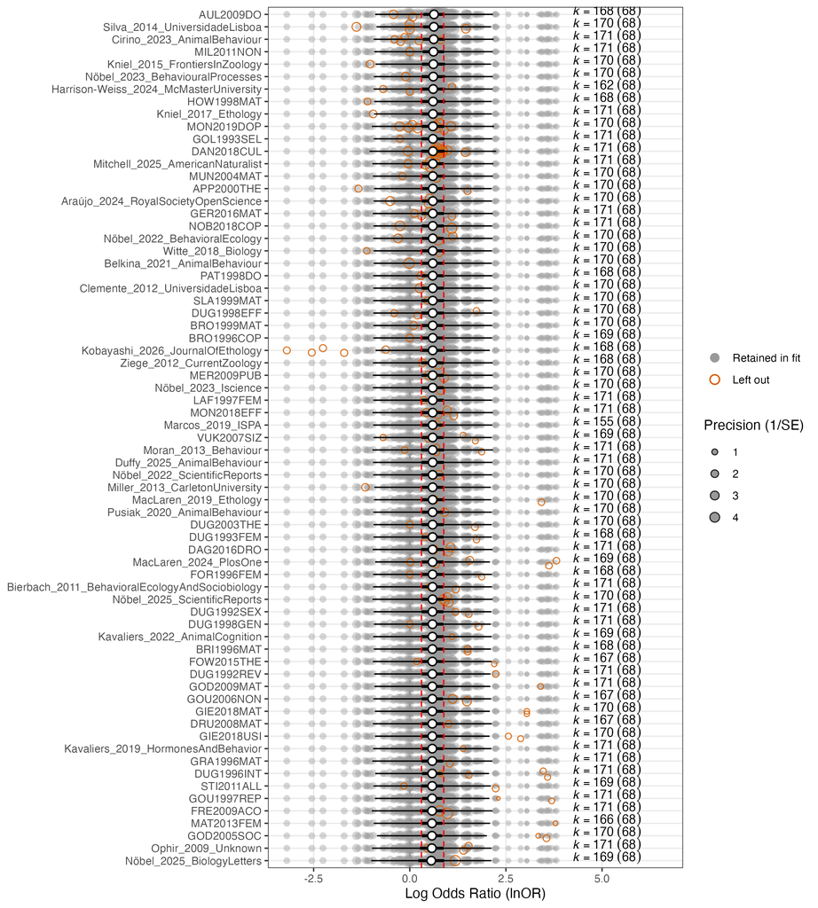

Figure 11: **Leave-one-study-out — odds ratio.**

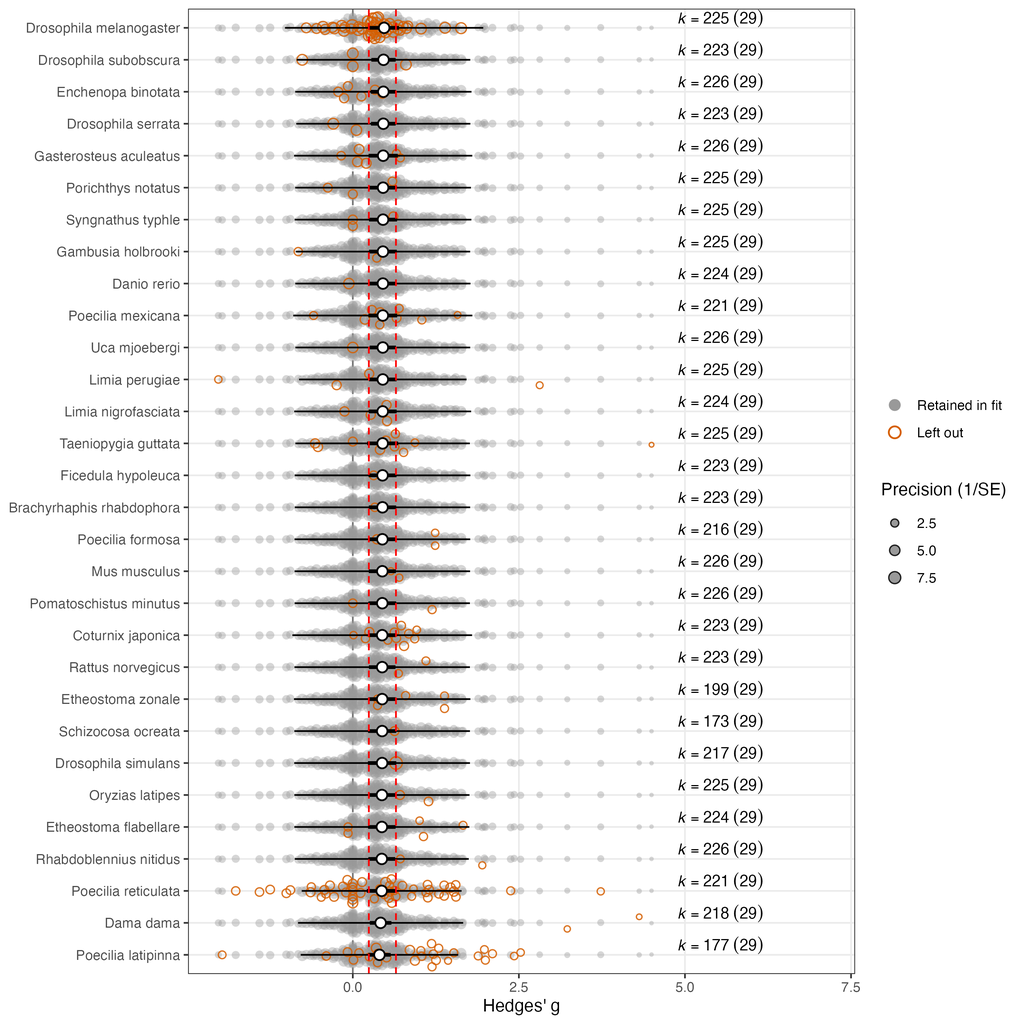

Figure 12: **Leave-one-species-out — Hedges’ g.**

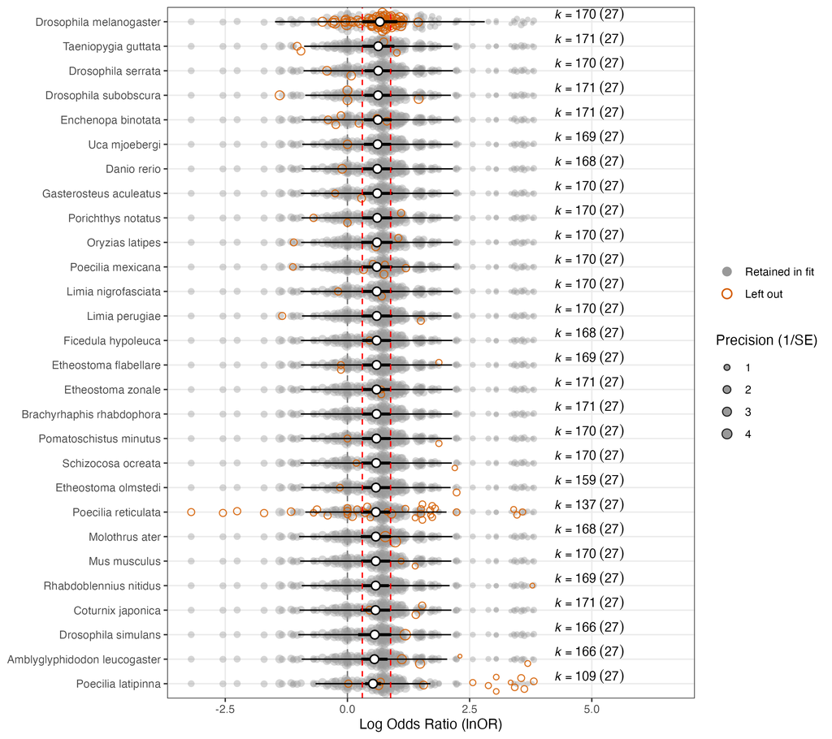

Figure 13: **Leave-one-species-out — odds ratio.**

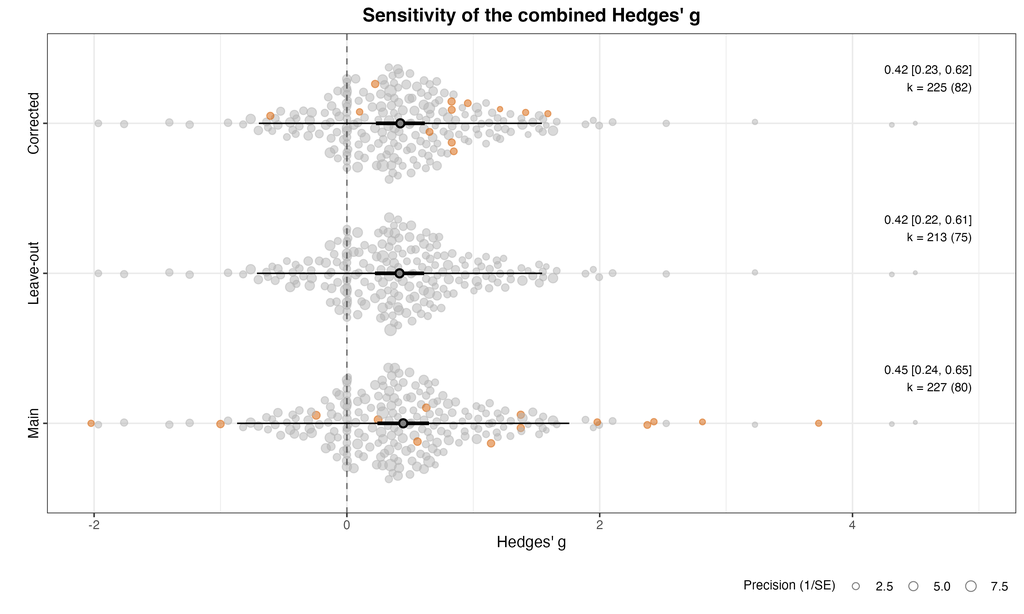

Figure 14: **Contentious effect sizes — Hedges’ g** (Main / Leave-out / Corrected).

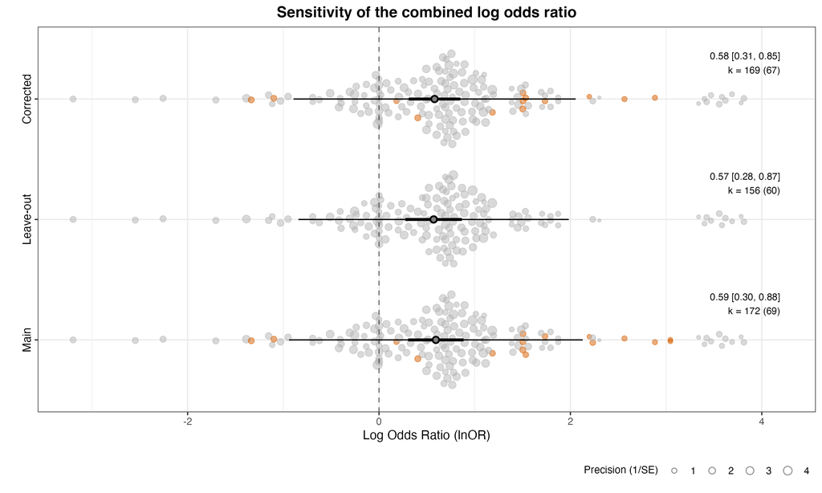

Figure 15: **Contentious effect sizes — odds ratio** (Main / Leave-out / Corrected).

# Bottom line

The qualitative conclusion of both original syntheses survives an expanded, more rigorous update: animals do copy the mate choices of others, and the pooled effect is positive and significant on both scales. But the effect is **more modest and more context-dependent** than previously implied — roughly half the original magnitude on its own, surrounded by large heterogeneity, and drawn close to (or below) zero under the more conservative bias correction.

**TipReproducibility**

This concise page transcribes the estimates reported in the manuscript and embeds the figures generated by the analysis pipeline. For the underlying data, model code, and complete diagnostics, see the full reproducible supplement at https://esantos2ua.github.io/mate_choice_meta/ and the repository at https://github.com/esantos2ua/mate_choice_meta.